# Trabalho Projeto de Dados

# Preparação do ambiente

Chamada das livrarias que precisarão para utilização de determinadas funções e geração dos gráficos para análise.

```r
library(readr)
library(dplyr)
library(tidyr)
library(ggplot2)
library(ggforce)
library(reactable)
library(htmltools)
library(reshape2)
library(gridExtra)
```

```r
remotes::install_github("kcuilla/reactablefmtr") #precisa da última versão 2.1.0 pra poder baixar tabelas, e install.packages n traz a última versão
```

```r
library("reactablefmtr")

reactable <- function(...) {
  htmltools::tagList(reactable::reactable(...))
}

getwd()
```

# Etapa 01: perguntas de pesquisa

Livros mais antigos são mais ou menos avaliados?

A quantidade de avaliações muda dependendo da empresa que publicou o livro?

Há alguma relação entre o autor do livro e as avaliações dadas?

# Etapa 02: base de dados

A base de dados utilizada é a do site Goodreads, plataforma online com mais de 125 milhões de usuários em que os leitores publicam avaliações e recomendações de livros.

A Goodreads disponibiliza uma API pública para consulta dos livros em sua base de dados (https://www.goodreads.com/api), mas ela foi desativada em dezembro de 2020, persistindo o acesso apenas aos usuários anteriores a essa data.

No site Kaggle, comunidade online de ciência de dados, foi disponibilizada por um usuário uma base de dados atualizada da data de 3 de dezembro de 2020 (https://www.kaggle.com/datasets/bahramjannesarr/goodreads-book-datasets-10m). Essa base de dados foi extraída da API do site Goodreads quando ela ainda funcionava.

# Etapa 03: qualidade dos dados

Ao analisar a base de dados, verificamos diversas questões a serem tratadas. A leitura de caracteres especiais e delimitadores foi feita corretamente, bem como o tratamento de casos nulos com “NA”. Porém, em alguns dos arquivos .csv, a coluna referente ao dia de publicação do livro se referia ao mês, e vice-versa; além disso, a coluna do número de páginas do livro também estava diferente em relação à letra maiúscula do cabeçalho, sendo tratado como diferentes pelo R, já que ele trata como case-sensitive.

```r
books_files <- list.files(pattern = "book.*csv", recursive=TRUE)

books_read <- vector("list",length(books_files))

for (i in 1:length(books_files)) {
  temp <- read_csv(books_files[i])
  if (max(temp$PublishMonth) > 12){
    colnames(temp)[colnames(temp)== "PublishMonth"] <- "pubday"
    colnames(temp)[colnames(temp)== "PublishDay"] <- "pubmonth"
  } else {
    colnames(temp)[colnames(temp)== "PublishDay"] <- "pubday"
    colnames(temp)[colnames(temp)== "PublishMonth"] <- "pubmonth"
  }
  colnames(temp)[colnames(temp)== "pagesNumber"] <- "PagesNumber"
  books_read[[i]] <- temp
}
```

```r
rm(temp)

books <- books_read %>%
  bind_rows()
```

Sendo tratadas o dia e mês da data de publicação, unimos os dois com o ano de publicação em uma única coluna com a data completa no formato DD/MM/AAAA. Também são tratadas as colunas referentes à quantidade de avaliações de cada quantidade de estrelas.

É importante destacar que há uma diferença entre “tipos de avaliações”: há as avaliações numéricas de 1 a 5 (“ratings”) e há as avaliações escritas (“reviews”).

```r
books$PublishDate <- paste(books$pubday, books$pubmonth, books$PublishYear, sep = "/") %>%
  as.Date("%d/%m/%Y")

for (i in 1:5) {
  coluna_estrela <- paste("RatingDist", i, sep = "")
  retirar_trecho <- paste(i, ":", sep = "")
  novo_nome_coluna <- paste("Ratings", i, "star", sep = "")

  books[c(coluna_estrela)] <- sub(retirar_trecho, '', books[[c(coluna_estrela)]]) %>%
    as.numeric()
  colnames(books)[colnames(books)== c(coluna_estrela)] <- novo_nome_coluna
}
books$RatingDistTotal <- sub("total:", "", books$RatingDistTotal) %>%
  as.numeric()
colnames(books)[colnames(books)== "RatingDistTotal"] <- 'TotalRatings'

books_problema_aval <- books %>%
  select(Id, Name, TotalRatings)
# Pode ser feita a mesma retirada dos trechos de cada coluna, mas utilizando a função "str_sub" da library "stringr":
# books <- books %>%
#   mutate(Ratings1star = str_sub(RatingDist1,3))
```

Pode ser realizada uma conferência se a soma das colunas referentes a cada avaliação é igual ao valor da coluna correspondente ao total de avaliações. Trazendo apenas valores TRUE significa que está correto.

```r
books_rating_check <- books %>%
  select(Ratings1star, Ratings2star, Ratings3star, Ratings4star, Ratings5star, TotalRatings) %>%
  mutate(TotalCheck = Ratings1star + Ratings2star + Ratings3star + Ratings4star + Ratings5star)
books_rating_check$check <- ifelse(books_rating_check$TotalCheck == books_rating_check$TotalRatings, TRUE, FALSE)
books_rating_check$check %>%
  table()
```

```
.
   TRUE
1850310
```

Selecionamos, então, apenas as colunas desejadas para as análises de variáveis e que serão utilizadas nos gráficos mais abaixo.

```r
books_selected <- books %>%
  select('Name', 'Authors', 'PublishDate', 'PublishYear', 'Language', 'Publisher', 'PagesNumber', 'Rating', 'Ratings1star', 'Ratings2star', 'Ratings3star', 'Ratings4star', 'Ratings5star', 'TotalRatings', 'CountsOfReview')
```

Confere-se um resumo geral da tabela com as informações selecionadas: se há algum ponto fora da curva, se as variáveis estão na classe desejada, etc.

```r
head(books_selected)
```

| Name | Authors | PublishDate | PublishYear | Language | Publisher | PagesNumber | Rating | Ratings1star | Ratings2star | Ratings3star | Ratings4star | Ratings5star | TotalRatings | CountsOfReview |
| --- | --- | --- | --- | --- | --- | --- | --- | --- | --- | --- | --- | --- | --- | --- |
| Harry Potter and the Half-Blood Prince (Harry Potter, #6) | J.K. Rowling | 2006-09-16 | 2006 | eng | Scholastic Inc. | 652 | 4.57 | 9896 | 25317 | 159960 | 556485 | 1546466 | 2298124 | 28062 |
| Harry Potter and the Order of the Phoenix (Harry Potter, #5) | J.K. Rowling | 2004-09-01 | 2004 | eng | Scholastic Inc. | 870 | 4.50 | 12455 | 37005 | 211781 | 604283 | 1493113 | 2358637 | 29770 |
| Harry Potter and the Sorcerer's Stone (Harry Potter, #1) | J.K. Rowling | 2003-11-01 | 2003 | eng | Scholastic Inc | 309 | 4.47 | 108202 | 130310 | 567458 | 1513191 | 4268227 | 6587388 | 75911 |
| Harry Potter and the Chamber of Secrets (Harry Potter, #2) | J.K. Rowling | 2003-11-01 | 2003 | eng | Scholastic | 352 | 4.42 | 11896 | 49353 | 288821 | 706082 | 1504505 | 2560657 | 244 |
| Harry Potter and the Prisoner of Azkaban (Harry Potter, #3) | J.K. Rowling | 2004-05-01 | 2004 | eng | Scholastic Inc. | 435 | 4.57 | 10128 | 24849 | 194848 | 630534 | 1749958 | 2610317 | 37093 |
| Harry Potter and the Goblet of Fire (Harry Potter, #4) | J.K. Rowling | 2002-09-28 | 2002 | eng | Scholastic | 734 | 4.56 | 9419 | 24282 | 178419 | 606800 | 1612165 | 2431085 | 31978 |

```r
summary(books_selected)
```

```
     Name             Authors           PublishDate          PublishYear      Language
 Length:1850310     Length:1850310     Min.   :0001-01-01   Min.   :    1   Length:1850310
 Class :character   Class :character   1st Qu.:1993-08-01   1st Qu.: 1993   Class :character
 Mode  :character   Mode  :character   Median :2000-06-12   Median : 2000   Mode  :character
                                       Mean   :1998-02-20   Mean   : 1998
                                       3rd Qu.:2005-03-01   3rd Qu.: 2005
                                       Max.   :6553-11-20   Max.   :65535
                                       NA's   :51
  Publisher          PagesNumber          Rating       Ratings1star       Ratings2star
 Length:1850310     Min.   :      0   Min.   :0.000   Min.   :     0.0   Min.   :     0.0
 Class :character   1st Qu.:    144   1st Qu.:2.000   1st Qu.:     0.0   1st Qu.:     0.0
 Mode  :character   Median :    239   Median :3.680   Median :     0.0   Median :     0.0
                    Mean   :    277   Mean   :2.894   Mean   :    94.4   Mean   :   207.2
                    3rd Qu.:    338   3rd Qu.:4.000   3rd Qu.:     1.0   3rd Qu.:     3.0
                    Max.   :4517845   Max.   :5.000   Max.   :550388.0   Max.   :544093.0

  Ratings3star        Ratings4star      Ratings5star      TotalRatings     CountsOfReview
 Min.   :      0.0   Min.   :      0   Min.   :     -2   Min.   :     -2   Min.   :     0.00
 1st Qu.:      0.0   1st Qu.:      0   1st Qu.:      0   1st Qu.:      1   1st Qu.:     0.00
 Median :      1.0   Median :      2   Median :      1   Median :      5   Median :     0.00
 Mean   :    754.6   Mean   :   1306   Mean   :   1717   Mean   :   4079   Mean   :    11.58
 3rd Qu.:     11.0   3rd Qu.:     15   3rd Qu.:     13   3rd Qu.:     44   3rd Qu.:     2.00
 Max.   :1013165.0   Max.   :1912159   Max.   :4608992   Max.   :7094687   Max.   :154447.00
```

```r
str(books_selected)
```

```
tibble [1,850,310 × 15] (S3: tbl_df/tbl/data.frame)
 $ Name          : chr [1:1850310] "Harry Potter and the Half-Blood Prince (Harry Potter, #6)" "Harry Potter and the Order of the Phoenix (Harry Potter, #5)" "Harry Potter and the Sorcerer's Stone (Harry Potter, #1)" "Harry Potter and the Chamber of Secrets (Harry Potter, #2)" ...
 $ Authors       : chr [1:1850310] "J.K. Rowling" "J.K. Rowling" "J.K. Rowling" "J.K. Rowling" ...
 $ PublishDate   : Date[1:1850310], format: "2006-09-16" "2004-09-01" "2003-11-01" ...
 $ PublishYear   : num [1:1850310] 2006 2004 2003 2003 2004 ...
 $ Language      : chr [1:1850310] "eng" "eng" "eng" "eng" ...
 $ Publisher     : chr [1:1850310] "Scholastic Inc." "Scholastic Inc." "Scholastic Inc" "Scholastic" ...
 $ PagesNumber   : num [1:1850310] 652 870 309 352 435 ...
 $ Rating        : num [1:1850310] 4.57 4.5 4.47 4.42 4.57 4.56 4.78 3.79 4.73 4.37 ...
 $ Ratings1star  : num [1:1850310] 9896 12455 108202 11896 10128 ...
 $ Ratings2star  : num [1:1850310] 25317 37005 130310 49353 24849 ...
 $ Ratings3star  : num [1:1850310] 159960 211781 567458 288821 194848 ...
 $ Ratings4star  : num [1:1850310] 556485 604283 1513191 706082 630534 ...
 $ Ratings5star  : num [1:1850310] 1546466 1493113 4268227 1504505 1749958 ...
 $ TotalRatings  : num [1:1850310] 2298124 2358637 6587388 2560657 2610317 ...
 $ CountsOfReview: num [1:1850310] 28062 29770 75911 244 37093 ...
```

Outliers

```r
color1 = "#0b0b0b" #"#011C50"
color2 = "#bebebe" #004A98"
color3 = "#ececeb" #011C50"
color4 = "#c7c7c7"

# linguagem dos livros
books_lang <- books_selected %>%
  group_by(Language) %>%
  summarise(count = n()) %>%
  arrange(desc(count))
books_lang
```

| Language | count |
| --- | --- |
| NA | 1598488 |
| eng | 180338 |
| en-US | 21489 |
| fre | 16327 |
| ger | 11470 |
| en-GB | 7767 |
| spa | 7245 |
| jpn | 2059 |
| ita | 1156 |
| mul | 417 |

[output cut: 115 more lines]

```r
qtd_livros <- nrow(books_selected)
qtd_livros
```

```
[1] 1850310
```

```r
qtd_books_lang <- books_lang %>%
  filter(count >= 100) %>%
  head(10) %>%
  pull(count) %>%
  sum()
qtd_books_lang
```

```
[1] 1846756
```

```r
porcent_livros_exibidos <- (qtd_books_lang/qtd_livros)*100
porcent_livros_exibidos <- sprintf("%1.2f%%", porcent_livros_exibidos)
livros_exibidos_msg <- paste("*representa", porcent_livros_exibidos, "da quantidade total de livros")
livros_exibidos_msg
```

```
[1] "*representa 99.81% da quantidade total de livros"
```

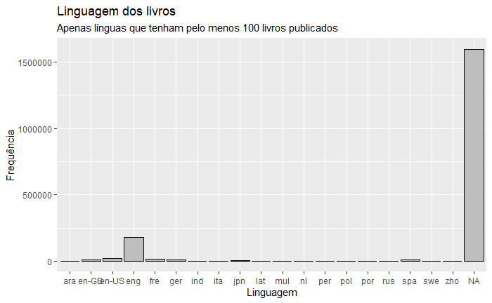

```r
books_lang %>%
  filter(count >= 100) %>%
  ggplot(aes(x = Language, y = count)) +
  geom_col(color = color1, fill = color2) +
  labs(title = "Linguagem dos livros", subtitle = "Apenas línguas que tenham pelo menos 100 livros publicados", x = "Linguagem", y = "Frequência")
```

```r
options(reactable.theme = reactableTheme(
  borderColor = color1,
  stripedColor = color3,
  style = list(fontFamily = "Arial"),
  headerStyle = list(background = color2),
  footerStyle = list(fontWeight = "bold"),
))

tbl <- books_lang %>%
  filter(count >= 100) %>%
  head(10) %>%
  reactable(
  defaultPageSize = 100,
  defaultColDef = colDef(
    align = "center",
    headerVAlign = "center",
    vAlign = "center"
  ),
  columns = list(
    Language = colDef(na = "\u274c",
                      width = 110,
                      name = "Linguagem",
                      footer = "Total"),
    count = colDef(
      width = 120,
      name = "Quantidade de livros",
      footer = function(values) sprintf("%i*", sum(values))
    )
  ),
  bordered = TRUE,
  highlight = TRUE,
  striped = TRUE,
  fullWidth = FALSE,
)


div(style="font-family: Arial, Times New Roman; color:#0b0b0b; text-align:center",
  div("Quantidade de livros por linguagem", style="font-size: 13.2pt; font-weight: bolder"),
  div("As 10 linguagens com mais livros", style="font-size: 11pt"),
  tbl,
  div(livros_exibidos_msg, style="font-size: 8.8pt")
)
```

Quantidade de livros por linguagem

As 10 linguagens com mais livros

| Linguagem | Quantidade de livros |
| --- | --- |
| NA | 1598488 |
| eng | 180338 |
| en-US | 21489 |
| fre | 16327 |
| ger | 11470 |
| en-GB | 7767 |
| spa | 7245 |
| jpn | 2059 |
| ita | 1156 |
| mul | 417 |

*representa 99.81% da quantidade total de livros

[figure not shown]

```r
print(ggplot(books_lang, aes(x = books_lang$Language, y = count)) +
             geom_col(color = color1, fill = color2) +
             labs(title = "Linguagem dos livros", subtitle = "Apenas línguas que tenham pelo menos 100 livros publicados", x = "Linguagem", y = "Frequência"))
```

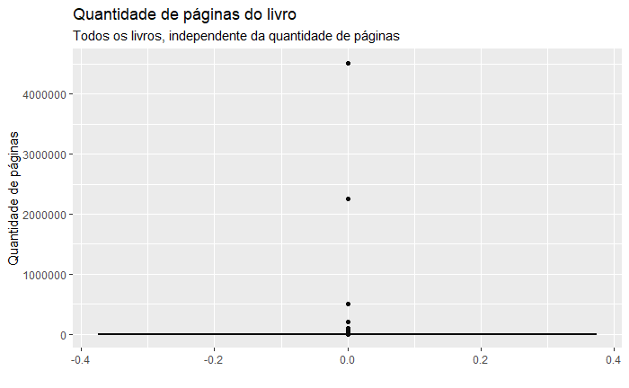

```r
############

windowsFonts("Arial" = windowsFont("Arial"))
print(ggplot(books_selected, aes(x = 0, y = PagesNumber)) +
      geom_boxplot(color = color1, fill = color2) +
      labs(title = "Quantidade de páginas do livro", subtitle = "Todos os livros, independente da quantidade de páginas", x = "", y = "Quantidade de páginas"))
```

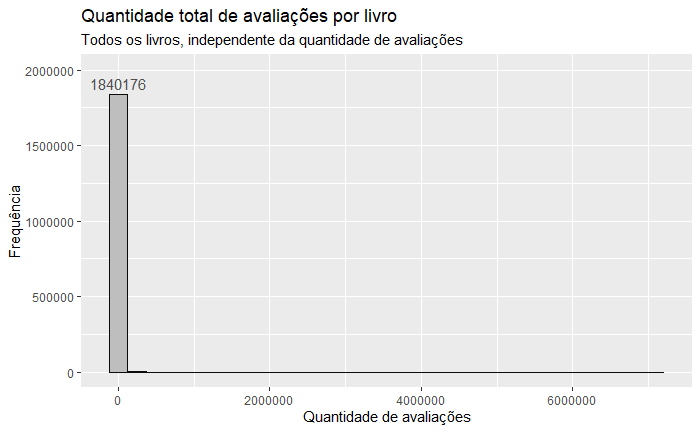

```r
      #theme_grey(base_family = "Arial") +
      #theme(axis.text = element_text(size = 12), title = element_text(colour = color1)))

##########

# total de avaliações
print(ggplot(books_selected, aes(x = TotalRatings)) +
             geom_histogram(color = color1, fill = color2) +
             ylim(0,2000000) +
             stat_bin(geom="text", colour = "grey30", aes(label = ifelse(..count.. == max(..count..), ..count.., "" )), vjust = -0.4) +
             labs(title = "Quantidade total de avaliações por livro", subtitle = "Todos os livros, independente da quantidade de avaliações", x = "Quantidade de avaliações", y = "Frequência"))
```

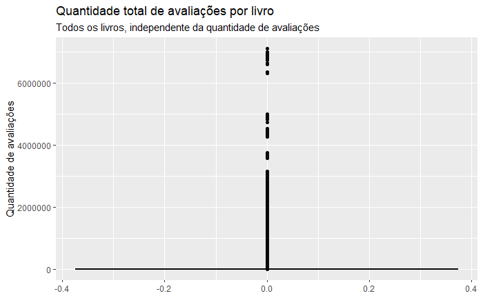

```r
print(ggplot(books_selected, aes(x = 0, y = TotalRatings)) +
      geom_boxplot(color = color1, fill = color2) +
      labs(title = "Quantidade total de avaliações por livro", subtitle = "Todos os livros, independente da quantidade de avaliações", x = NULL, y = "Quantidade de avaliações"))
```

# Etapa 4: estatísticas descritivas

rating qtd ratings qtd reviews qtd de livros por ano de publicação numero de páginas *qtd 1 estrela* qtd 5 estrela

```r
# Não exibir os valores em notação científica
options(scipen=999)

# Função pra calcular a moda
getmode <- function(v) {
   uniqv <- unique(v)
   uniqv[which.max(tabulate(match(v, uniqv)))]
}

books_estat_descritivas <- books_selected %>%
  select (PagesNumber, PublishYear, Rating, TotalRatings, CountsOfReview) %>%
  rename ("Numero_paginas" = PagesNumber,
          "Ano_publicacao" = PublishYear,
          "Avaliacao_media" = Rating,
          "Total_avaliacoes" = TotalRatings,
          "Total_resenhas" = CountsOfReview)
```

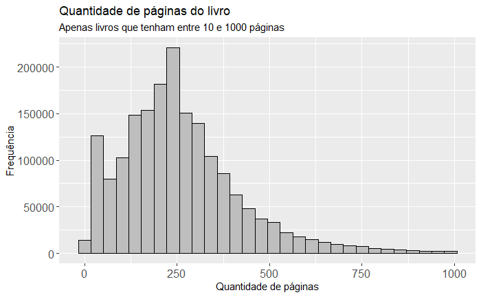

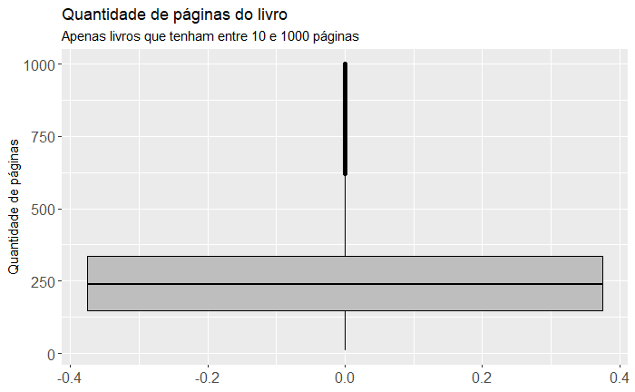

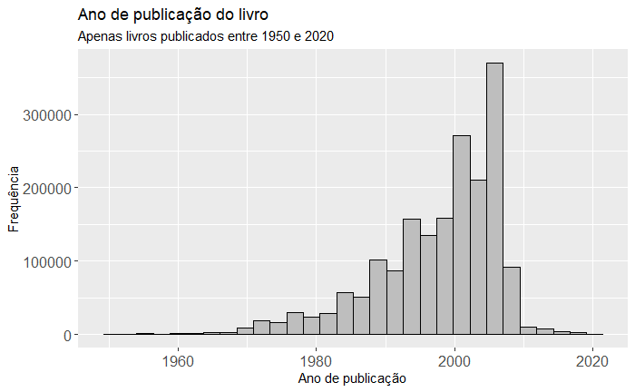

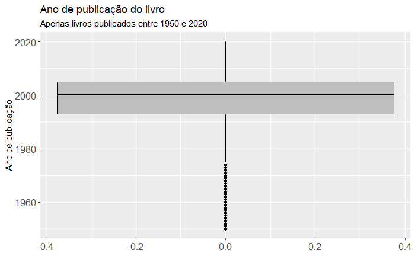

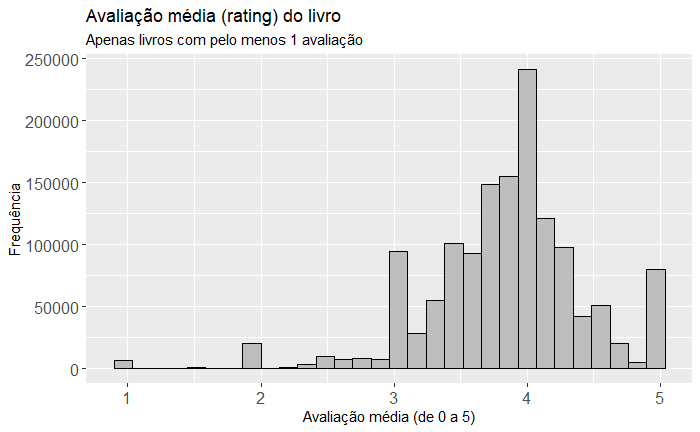

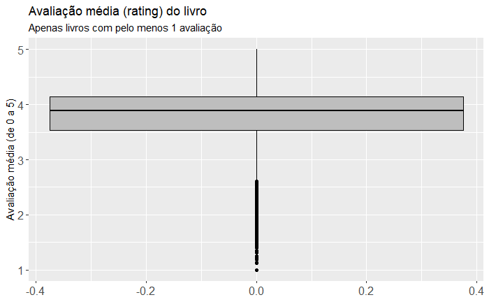

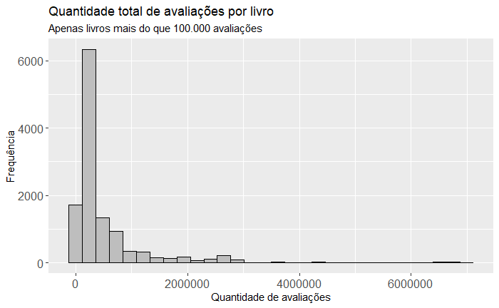

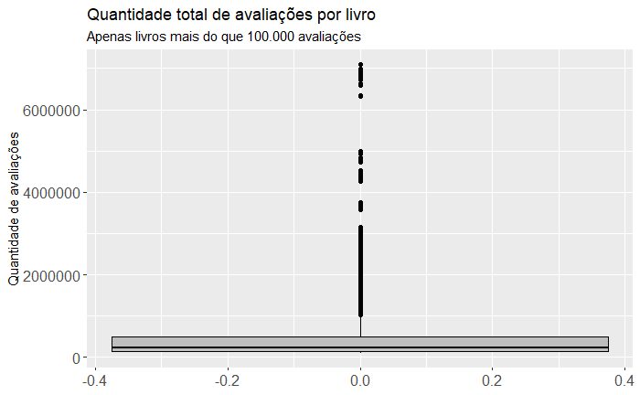

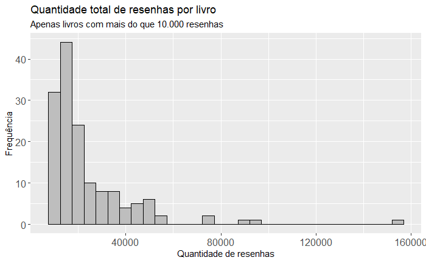

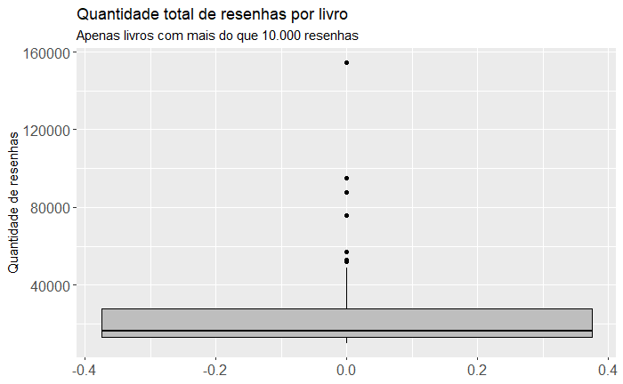

```r
color1 = "black"
color2 = "grey"

for(i in 1:5){
  resumo <- books_estat_descritivas %>%
    summarise("Número de observações" = n(),
              "Mínimo" = min(books_estat_descritivas[[i]]),
              "Máximo" = max(books_estat_descritivas[[i]]),
              "Média" = round(mean(books_estat_descritivas[[i]]), digits=2),
              "Moda" = round(getmode(books_estat_descritivas[[i]]), digits=2),
              "Mediana" = round(median(books_estat_descritivas[[i]], digits=2)),
              "Desvio padrão" = round(sd(books_estat_descritivas[[i]]), digits=2)) %>%
    melt()

  tabela_resumo <- resumo %>%
    reactable(
      defaultColDef = colDef(
        align = "center",
        headerVAlign = "center",
        vAlign = "center"
      ),
      columns = list(
        variable = colDef(
          na = "\u274c",
          width = 220,
          name = "Variável"
        ),
        value = colDef(
          width = 200,
          name = "Valor"
        )
      ),
      bordered = TRUE,
      highlight = TRUE,
      striped = TRUE,
      fullWidth = FALSE,
    )

  switch (i,
    '1' = {title = "Numero de páginas do livro"},
    '2' = {title = "Ano de publicação do livro"},
    '3' = {title = "Avaliação média do livro"},
    '4' = {title = "Total de avaliações (ratings) do livro"},
    '5' = {title = "Total de resenhas (reviews) do livro"},
    "Sem título"
  )

  div(style="font-family: Arial, Times New Roman; color:#0b0b0b; text-align:center",
    div(title, style="font-size: 13.2pt; font-weight: bolder"),
    div("Todos os livros", style="font-size: 11pt"),
    tabela_resumo
  )

  switch (i,
    '1' = {intervalo_paginas <- books_estat_descritivas %>%
              filter(Numero_paginas >= 10 & Numero_paginas <= 1000)
           print(ggplot(intervalo_paginas, aes(x = Numero_paginas)) +
                 geom_histogram(color = color1, fill = color2) +
                 labs(title = "Quantidade de páginas do livro", subtitle = "Apenas livros que tenham entre 10 e 1000 páginas", x = "Quantidade de páginas", y = "Frequência") +
                 theme(axis.text = element_text(size = 12)))
           print(ggplot(intervalo_paginas, aes(y = Numero_paginas)) +
                 geom_boxplot(color = color1, fill = color2) +
                 labs(title = "Quantidade de páginas do livro", subtitle = "Apenas livros que tenham entre 10 e 1000 páginas", x = NULL, y = "Quantidade de páginas") +
                 theme(axis.text = element_text(size = 12)))
    },
    '2' = {intervalo_anos <- books_estat_descritivas %>%
              filter(Ano_publicacao >= 1950 & Ano_publicacao <= 2020)
           print(ggplot(intervalo_anos, aes(x = Ano_publicacao)) +
                 geom_histogram(color = color1, fill = color2) +
                 labs(title = "Ano de publicação do livro", subtitle = "Apenas livros publicados entre 1950 e 2020", x = "Ano de publicação", y = "Frequência") +
                 theme(axis.text = element_text(size = 12)))
           print(ggplot(intervalo_anos, aes(y = Ano_publicacao)) +
                 geom_boxplot(color = color1, fill = color2) +
                 labs(title = "Ano de publicação do livro", subtitle = "Apenas livros publicados entre 1950 e 2020", x = NULL, y = "Ano de publicação") +
                 theme(axis.text = element_text(size = 12)))
    },
    '3' = {min_avaliacoes <- books_estat_descritivas %>%
              filter(Total_avaliacoes > 0)
           print(ggplot(min_avaliacoes, aes(x = Avaliacao_media)) +
                 geom_histogram(color = color1, fill = color2) +
                 labs(title = "Avaliação média (rating) do livro", subtitle = "Apenas livros com pelo menos 1 avaliação", x = "Avaliação média (de 0 a 5)", y = "Frequência") +
                 theme(axis.text = element_text(size = 12)))
           print(ggplot(min_avaliacoes, aes(y = Avaliacao_media)) +
                 geom_boxplot(color = color1, fill = color2) +
                 labs(title = "Avaliação média (rating) do livro", subtitle = "Apenas livros com pelo menos 1 avaliação", x = NULL, y = "Avaliação média (de 0 a 5)") +
                 theme(axis.text = element_text(size = 12)))
    },
    '4' = {min_avaliacoes <- books_estat_descritivas %>%
              filter(Total_avaliacoes > 100000)
           print(ggplot(min_avaliacoes, aes(x = Total_avaliacoes)) +
                 geom_histogram(color = color1, fill = color2) +
                 labs(title = "Quantidade total de avaliações por livro", subtitle = "Apenas livros mais do que 100.000 avaliações", x = "Quantidade de avaliações", y = "Frequência") +
                 theme(axis.text = element_text(size = 12)))
           print(ggplot(min_avaliacoes, aes(y = Total_avaliacoes)) +
                 geom_boxplot(color = color1, fill = color2) +
                 labs(title = "Quantidade total de avaliações por livro", subtitle = "Apenas livros mais do que 100.000 avaliações", x = NULL, y = "Quantidade de avaliações") +
                 theme(axis.text = element_text(size = 12)))
    },
    '5' = {min_resenhas <- books_estat_descritivas %>%
              filter(Total_resenhas > 10000)
           print(ggplot(min_resenhas, aes(x = Total_resenhas)) +
                 geom_histogram(color = color1, fill = color2) +
                 labs(title = "Quantidade total de resenhas por livro", subtitle = "Apenas livros com mais do que 10.000 resenhas", x = "Quantidade de resenhas", y = "Frequência") +
                 theme(axis.text = element_text(size = 12)))
           print(ggplot(min_resenhas, aes(y = Total_resenhas)) +
                 geom_boxplot(color = color1, fill = color2) +
                 labs(title = "Quantidade total de resenhas por livro", subtitle = "Apenas livros com mais do que 10.000 resenhas", x = NULL, y = "Quantidade de resenhas") +
                 theme(axis.text = element_text(size = 12)))
    },
    print("Variável não esperada")
  )
  plot.new()
  dev.off()
}
```

```r
#### estatísticas descritivas
i=5

resumo <- books_estat_descritivas %>%
    summarise("Número de observações" = n(),
              "Mínimo" = min(books_estat_descritivas[[i]]),
              "Máximo" = max(books_estat_descritivas[[i]]),
              "Média" = round(mean(books_estat_descritivas[[i]]), digits=2),
              "Moda" = round(getmode(books_estat_descritivas[[i]]), digits=2),
              "Mediana" = round(median(books_estat_descritivas[[i]], digits=2)),
              "Desvio padrão" = round(sd(books_estat_descritivas[[i]]), digits=2)) %>%
    melt()
switch (i,
    '1' = {title = "Numero de páginas do livro"},
    '2' = {title = "Ano de publicação do livro"},
    '3' = {title = "Avaliação média do livro"},
    '4' = {title = "Total de avaliações (ratings) do livro"},
    '5' = {title = "Total de resenhas (reviews) do livro"},
    "Sem título"
  )

tabela_resumo <- resumo %>%
    reactable(
      defaultColDef = colDef(
        align = "center",
        headerVAlign = "center",
        vAlign = "center"
      ),
      columns = list(
        variable = colDef(
          na = "\u274c",
          width = 200,
          name = "Variável"
        ),
        value = colDef(
          width = 140,
          name = "Valor",
          format = colFormat(separators = TRUE, locales = "pt-BR")
        )
      ),
      bordered = TRUE,
      highlight = TRUE,
      striped = TRUE,
      fullWidth = FALSE,
    )

div(style="font-family: Arial, Times New Roman; color:#0b0b0b; text-align:center",
    div(title, style="font-size: 13.2pt; font-weight: bolder"),
    div("Variável quantitativa discreta", style="font-size: 11pt"),
    tabela_resumo,
  )
```

Total de resenhas (reviews) do livro

Variável quantitativa discreta

| Variável | Valor |
| --- | --- |
| Número de observações | 1850310 |
| Mínimo | 0 |
| Máximo | 154447 |
| Média | 11.58 |
| Moda | 0 |
| Mediana | 0 |
| Desvio padrão | 295.27 |

```r
NA
```